# Table of Contents

**Kernel Author:**  
[Bhishan Poudel, Data Scientist, Ph.D Astrophysics](https://bhishanpdl.github.io/) .

# Data Description

> The datasets contains transactions made by credit cards in September 2013 by european cardholders.

> This dataset presents transactions that occurred in two days, where we have 492 frauds out of 284,807 transactions.

> The dataset is highly unbalanced, the positive class (frauds) account for 0.172% of all transactions.

> It contains only numerical input variables which are the result of a PCA transformation.

> Unfortunately, due to confidentiality issues, we cannot provide the original features and more background information about the data.

> Features V1, V2, ... V28 are the principal components obtained with PCA, the only features which have not been transformed with PCA are 'Time' and 'Amount'.

> Feature 'Time' contains the seconds elapsed between each transaction and the first transaction in the dataset. The feature 'Amount' is the transaction Amount, this feature can be used for example-dependant cost-senstive learning.

> Feature 'Class' is the response variable and it takes value 1 in case of fraud and 0 otherwise.m

# Business Problem

# Introduction to Pycaret

[Pycaret](https://github.com/pycaret/pycaret) is a high level python module which requires very few lines of code to solve the machine learning problem at hand. This module is useful when dealing with projects with extreme less time constraints.

It has classes like

```
anomaly, classification, clustering, datasets,
nlp, preprecess and regression
```

.

Some resources for pycaret:

- [pycaret github](https://github.com/pycaret/pycaret)
- [pycaret classification 101](https://github.com/pycaret/pycaret/blob/master/Tutorials/Binary%20Classification%20Tutorial%20Level%20Beginner%20-%20%20CLF101.ipynb)
- [pycaret classification 102](https://github.com/pycaret/pycaret/blob/master/Tutorials/Binary%20Classification%20Tutorial%20Level%20Intermediate%20-%20CLF102.ipynb)
- [Running Low on Time? Use PyCaret to Build your Machine Learning Model in Seconds](https://www.analyticsvidhya.com/blog/2020/05/pycaret-machine-learning-model-seconds/)

**Technical Note**  
For google colab use:

```
from pycaret.utils import enable_colab
enable_colab()
```

# Imports

```python
import time

notebook_start_time = time.time()
```

```python
import bhishan
```

```python
%load_ext autoreload
```

```
The autoreload extension is already loaded. To reload it, use:
  %reload_ext autoreload
```

```python
%autoreload 2
```

```python
import numpy as np
import pandas as pd
import seaborn as sns
import os
from pathlib import Path

from tqdm import tqdm_notebook as tqdm
import matplotlib.pyplot as plt

%matplotlib inline
%config InlineBackend.figure_format = 'retina'
plt.style.use('ggplot')

# random state
SEED=100

home = os.path.expanduser('~')

[(x.__name__,x.__version__) for x in [np,pd,sns]]
```

```
[('numpy', '1.18.4'), ('pandas', '1.0.4'), ('seaborn', '0.10.1')]
```

```python
import pycaret
from pycaret.utils import version
import pycaret.classification as pyc

version()
```

```
1.0.0
```

```python
from zipfile import ZipFile
```

```python
import sys
ENV_COLAB = 'google.colab' in sys.modules

if ENV_COLAB:
    #!pip install hpsklearn
    !pip install shap eli5
    !pip install catboost
    !pip install ipywidgets
    !jupyter nbextension enable --py widgetsnbextension

    # set OMP_NUM_THREADS=1 for hpsklearn package
    #!export OMP_NUM_THREADS=1
    print('Environment: Google Colab')
```

# Useful Functions

```python
def compare_new_models(name,desc,mean_row,df_eval=None,sort='Accuracy',show=True):
    """Create dataframe from output of pycaret new model.
    Parameters
    -----------
    name: str
        Name of the model. eg. xgboost
    desc: str
        Description of the model. e.g tuned,calibrated
    mean_row: str
        The line copied from jupyter notebook output from
        pycaret new model. Note that fields are separated
        with tabs.
        e.g.
        Mean	0.9992	0.9663	0.7214	0.8299	0.7679	0.7675
    df_eval: Pandas Dataframe
        Template pandas dataframe
    sort: str
       One of following string: Accuracy, AUC, Recall, Precision
                                F1, Kappa


    Returns:
       Pandas Dataframe.


    """
    mean_row_lst = mean_row.split('\t')
    assert len(mean_row_lst) == 7

    if not isinstance(df_eval, pd.DataFrame):
        df_eval = pd.DataFrame({'Model': [],
                                'Description':[],
                                'Accuracy':[],
                                'AUC':[],
                                'Recall':[],
                                'Precision':[],
                                'F1':[],
                                'Kappa':[]
                               })

    acc,auc,rec,pre,f1,kap = mean_row.split('\t')[1:]
    row = [name,desc,acc,auc,rec,pre,f1,kap]

    df_eval.loc[len(df_eval)] = row
    df_eval = df_eval.drop_duplicates()\
                     .sort_values(sort,ascending=False)
    df_eval.index = range(len(df_eval))

    df_style = (df_eval.style.apply(lambda ser:
                ['background: lightblue'
                 if ser.name == sort else ''
                 for _ in ser]))

    if show:
        display(df_style)

    return df_eval
```

# Load the data

```python
# ifile = 'https://github.com/bhishanpdl/Datasets/blob/master/fraud_detection/creditcard.csv.zip?raw=true'
# df = pd.read_csv(ifile,compression='zip')
# print(df.shape)
# df.head()
```

```python
ifile = Path.home() / 'Datasets/kaggle/creditcard/creditcard.csv.zip'
zip_file = ZipFile(ifile)
df = pd.read_csv(zip_file.open('creditcard.csv'))
print(df.shape)
df.head()
```

```
(284807, 31)
```

|  | Time | V1 | V2 | V3 | V4 | V5 | V6 | V7 | V8 | V9 | ... | V21 | V22 | V23 | V24 | V25 | V26 | V27 | V28 | Amount | Class |
| --- | --- | --- | --- | --- | --- | --- | --- | --- | --- | --- | --- | --- | --- | --- | --- | --- | --- | --- | --- | --- | --- |
| 0 | 0.0 | -1.359807 | -0.072781 | 2.536347 | 1.378155 | -0.338321 | 0.462388 | 0.239599 | 0.098698 | 0.363787 | ... | -0.018307 | 0.277838 | -0.110474 | 0.066928 | 0.128539 | -0.189115 | 0.133558 | -0.021053 | 149.62 | 0 |
| 1 | 0.0 | 1.191857 | 0.266151 | 0.166480 | 0.448154 | 0.060018 | -0.082361 | -0.078803 | 0.085102 | -0.255425 | ... | -0.225775 | -0.638672 | 0.101288 | -0.339846 | 0.167170 | 0.125895 | -0.008983 | 0.014724 | 2.69 | 0 |
| 2 | 1.0 | -1.358354 | -1.340163 | 1.773209 | 0.379780 | -0.503198 | 1.800499 | 0.791461 | 0.247676 | -1.514654 | ... | 0.247998 | 0.771679 | 0.909412 | -0.689281 | -0.327642 | -0.139097 | -0.055353 | -0.059752 | 378.66 | 0 |
| 3 | 1.0 | -0.966272 | -0.185226 | 1.792993 | -0.863291 | -0.010309 | 1.247203 | 0.237609 | 0.377436 | -1.387024 | ... | -0.108300 | 0.005274 | -0.190321 | -1.175575 | 0.647376 | -0.221929 | 0.062723 | 0.061458 | 123.50 | 0 |
| 4 | 2.0 | -1.158233 | 0.877737 | 1.548718 | 0.403034 | -0.407193 | 0.095921 | 0.592941 | -0.270533 | 0.817739 | ... | -0.009431 | 0.798278 | -0.137458 | 0.141267 | -0.206010 | 0.502292 | 0.219422 | 0.215153 | 69.99 | 0 |

5 rows × 31 columns

```python
target = 'Class'
features = df.columns.drop(target)
df[target].value_counts(normalize=True)*100
```

```
0    99.827251
1     0.172749
Name: Class, dtype: float64
```

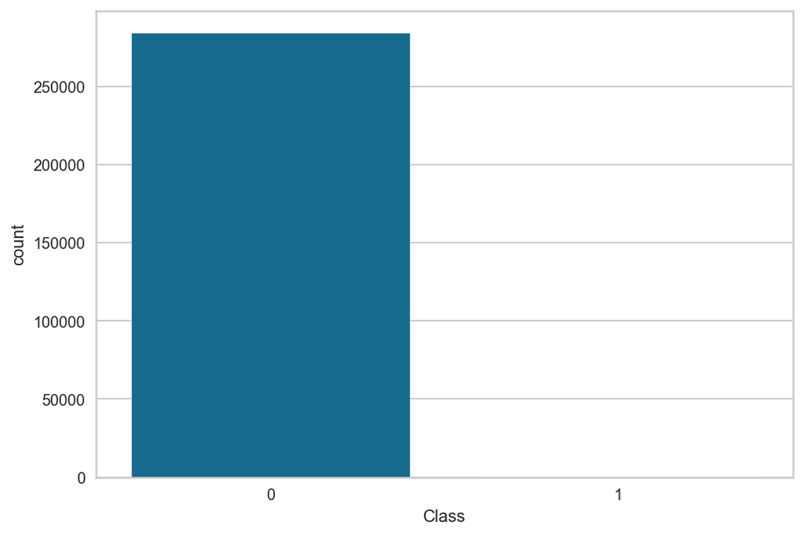

```python
sns.countplot(df[target])
```

# Train test split with stratify

```python
from sklearn.model_selection import train_test_split

df_train, df_test = train_test_split(
    df,test_size=0.2, random_state=SEED,
    stratify=df[target])

print(df_train.shape)
df_train.head()
```

```
(227845, 31)
```

|  | Time | V1 | V2 | V3 | V4 | V5 | V6 | V7 | V8 | V9 | ... | V21 | V22 | V23 | V24 | V25 | V26 | V27 | V28 | Amount | Class |
| --- | --- | --- | --- | --- | --- | --- | --- | --- | --- | --- | --- | --- | --- | --- | --- | --- | --- | --- | --- | --- | --- |
| 211885 | 138616.0 | -1.137612 | 2.345154 | -1.767247 | 0.833982 | 0.973168 | -0.073571 | 0.802433 | 0.733137 | -1.154087 | ... | 0.114953 | 0.430613 | -0.240819 | 0.124011 | 0.187187 | -0.402251 | 0.196277 | 0.190732 | 39.46 | 0 |
| 12542 | 21953.0 | -1.028649 | 1.141569 | 2.492561 | -0.242233 | 0.452842 | -0.384273 | 1.256026 | -0.816401 | 1.964560 | ... | -0.380356 | -0.037432 | -0.503934 | 0.407129 | 0.604252 | 0.233015 | -0.433132 | -0.491892 | 7.19 | 0 |
| 270932 | 164333.0 | -1.121864 | -0.195099 | 1.282634 | -3.172847 | -0.761969 | -0.287013 | -0.586367 | 0.496182 | -2.352349 | ... | -0.328953 | -0.856937 | -0.056198 | 0.401905 | 0.406813 | -0.440140 | 0.152356 | 0.030128 | 40.00 | 0 |
| 30330 | 35874.0 | 1.094238 | -0.760568 | -0.392822 | -0.611720 | -0.722850 | -0.851978 | -0.185505 | -0.095131 | -1.122304 | ... | -0.227392 | -1.254285 | 0.022116 | -0.141531 | 0.114515 | -0.652427 | -0.037897 | 0.051254 | 165.85 | 0 |
| 272477 | 165107.0 | 2.278095 | -1.298924 | -1.884035 | -1.530435 | -0.649500 | -0.996024 | -0.466776 | -0.438025 | -1.612665 | ... | 0.123892 | 0.815909 | -0.072537 | 0.784217 | 0.403428 | 0.193747 | -0.043185 | -0.058719 | 60.00 | 0 |

5 rows × 31 columns

# Pycaret Setup

- `setup` function will automatically infer datatypes, but if we see wrong data inference, we can use parameters `numeric_features` and `categorical_features`.

```python
from bhishan import bp
bp.show_method_attributes(pyc,4)
```

|  | 0 | 1 | 2 | 3 |
| --- | --- | --- | --- | --- |
| 0 | X | deploy_model | load_model | seed |
| 1 | X_test | ensemble_model | optimize_threshold | setup |
| 2 | X_train | evaluate_model | plot_model | stack_models |
| 3 | blend_models | experiment__ | predict_model | tune_model |
| 4 | calibrate_model | finalize_model | prep_pipe | y |
| 5 | compare_models | interpret_model | save_experiment | y_test |
| 6 | create_model | load_experiment | save_model | y_train |
| 7 | create_stacknet |  |  |  |

```python
# pyc.setup?
```

```
setup(data, target, train_size=0.7, sampling=True, sample_estimator=None, categorical_features=None, categorical_imputation='constant', ordinal_features=None, high_cardinality_features=None, high_cardinality_method='frequency', numeric_features=None, numeric_imputation='mean', date_features=None, ignore_features=None, normalize=False, normalize_method='zscore', transformation=False, transformation_method='yeo-johnson', handle_unknown_categorical=True, unknown_categorical_method='least_frequent', pca=False, pca_method='linear', pca_components=None, ignore_low_variance=False, combine_rare_levels=False, rare_level_threshold=0.1, bin_numeric_features=None, remove_outliers=False, outliers_threshold=0.05, remove_multicollinearity=False, multicollinearity_threshold=0.9, create_clusters=False, cluster_iter=20, polynomial_features=False, polynomial_degree=2, trigonometry_features=False, polynomial_threshold=0.1, group_features=None, group_names=None, feature_selection=False, feature_selection_threshold=0.8, feature_interaction=False, feature_ratio=False, interaction_threshold=0.01, session_id=None, silent=False, profile=False)
```

```python
experiment_may31_2020 = pyc.setup(df_train,'Class', session_id=1)
```

```
Setup Succesfully Completed!
```

[output not shown]

# Comparing All Models

- compare using stratified cross validation for metric evaluation.
- shows average metrics for score grid for 10 fold cross-validation
- default sorting is accuracy

```
compare_models(blacklist = None,fold = 10, round = 4,
               sort = 'Accuracy',turbo = True)
```

```python
pyc.compare_models(sort = 'Recall',fold=5)
```

|  | Model | Accuracy | AUC | Recall | Prec. | F1 | Kappa |
| --- | --- | --- | --- | --- | --- | --- | --- |
| 0 | Quadratic Discriminant Analysis | 0.983000 | 0.943700 | 0.800900 | 0.081500 | 0.147600 | 0.144900 |
| 1 | Extreme Gradient Boosting | 0.999400 | 0.958500 | 0.734500 | 0.910200 | 0.804700 | 0.804400 |
| 2 | CatBoost Classifier | 0.999500 | 0.955400 | 0.734500 | 0.954800 | 0.821500 | 0.821200 |
| 3 | Linear Discriminant Analysis | 0.999200 | 0.967700 | 0.725500 | 0.834000 | 0.766100 | 0.765700 |
| 4 | Extra Trees Classifier | 0.999400 | 0.915500 | 0.694500 | 0.950700 | 0.797000 | 0.796700 |
| 5 | Decision Tree Classifier | 0.998500 | 0.832700 | 0.666400 | 0.591600 | 0.618100 | 0.617400 |
| 6 | Random Forest Classifier | 0.999300 | 0.895200 | 0.636400 | 0.918100 | 0.747300 | 0.746900 |
| 7 | Logistic Regression | 0.998800 | 0.902700 | 0.596400 | 0.705300 | 0.636300 | 0.635700 |
| 8 | Naive Bayes | 0.992100 | 0.947200 | 0.596400 | 0.129300 | 0.211800 | 0.209500 |
| 9 | Ada Boost Classifier | 0.998900 | 0.944800 | 0.530000 | 0.806700 | 0.629100 | 0.628700 |
| 10 | Gradient Boosting Classifier | 0.998600 | 0.694900 | 0.441800 | 0.565800 | 0.483800 | 0.483200 |
| 11 | Ridge Classifier | 0.998700 | 0.000000 | 0.356400 | 0.827900 | 0.481600 | 0.481100 |
| 12 | Light Gradient Boosting Machine | 0.988500 | 0.371200 | 0.100900 | 0.040200 | 0.056800 | 0.054300 |
| 13 | K Neighbors Classifier | 0.998300 | 0.551600 | 0.000000 | 0.000000 | 0.000000 | 0.000000 |
| 14 | SVM - Linear Kernel | 0.998200 | 0.000000 | 0.000000 | 0.000000 | 0.000000 | -0.000200 |

# Create Models

- 'lr', 'knn', 'nb', 'dt', 'svm', 'rbfsvm', 'gpc'
- 'mlp' (Multi Level Perceptron)
- 'ridge', 'rf', 'qda'
- 'ada' (AdaBoost)
- 'gbc' (Gradient Boosting)
- 'lda', 'et'
- 'xgboost' (Extreme Gradient Boosting)
- 'lightgbm', 'catboost'

```python
# pyc.create_model?
```

```python
# build the xgboost model
clf_xgb = pyc.create_model('xgboost')
```

|  | Accuracy | AUC | Recall | Prec. | F1 | Kappa |
| --- | --- | --- | --- | --- | --- | --- |
| 0 | 0.9995 | 0.9549 | 0.8000 | 0.8889 | 0.8421 | 0.8419 |
| 1 | 0.9992 | 0.9258 | 0.6000 | 0.8571 | 0.7059 | 0.7055 |
| 2 | 0.9997 | 0.9985 | 0.8000 | 1.0000 | 0.8889 | 0.8887 |
| 3 | 0.9995 | 0.9032 | 0.8000 | 0.8889 | 0.8421 | 0.8419 |
| 4 | 0.9997 | 0.9999 | 1.0000 | 0.8333 | 0.9091 | 0.9089 |
| 5 | 0.9993 | 0.9839 | 0.6364 | 1.0000 | 0.7778 | 0.7775 |
| 6 | 0.9988 | 0.8939 | 0.4545 | 0.8333 | 0.5882 | 0.5877 |
| 7 | 0.9995 | 0.9366 | 0.7273 | 1.0000 | 0.8421 | 0.8419 |
| 8 | 0.9992 | 0.9901 | 0.7273 | 0.8000 | 0.7619 | 0.7615 |
| 9 | 0.9997 | 0.9979 | 0.8000 | 1.0000 | 0.8889 | 0.8887 |
| Mean | 0.9994 | 0.9585 | 0.7345 | 0.9102 | 0.8047 | 0.8044 |
| SD | 0.0003 | 0.0391 | 0.1392 | 0.0774 | 0.0940 | 0.0942 |

```python
mean_row = 'Mean	0.9994	0.9585	0.7345	0.9102	0.8047	0.8044'
df_eval = compare_new_models('xgb','default',mean_row)
```

|  | Model | Description | Accuracy | AUC | Recall | Precision | F1 | Kappa |
| --- | --- | --- | --- | --- | --- | --- | --- | --- |
| 0 | xgb | default | 0.9994 | 0.9585 | 0.7345 | 0.9102 | 0.8047 | 0.8044 |

```python
clf_cb = pyc.create_model('catboost')
```

|  | Accuracy | AUC | Recall | Prec. | F1 | Kappa |
| --- | --- | --- | --- | --- | --- | --- |
| 0 | 0.9993 | 0.9587 | 0.7000 | 0.8750 | 0.7778 | 0.7774 |
| 1 | 0.9993 | 0.9506 | 0.7000 | 0.8750 | 0.7778 | 0.7774 |
| 2 | 0.9997 | 0.9995 | 0.8000 | 1.0000 | 0.8889 | 0.8887 |
| 3 | 0.9995 | 0.9177 | 0.8000 | 0.8889 | 0.8421 | 0.8419 |
| 4 | 0.9998 | 0.9999 | 1.0000 | 0.9091 | 0.9524 | 0.9523 |
| 5 | 0.9993 | 0.9727 | 0.6364 | 1.0000 | 0.7778 | 0.7775 |
| 6 | 0.9990 | 0.8430 | 0.4545 | 1.0000 | 0.6250 | 0.6246 |
| 7 | 0.9995 | 0.9314 | 0.7273 | 1.0000 | 0.8421 | 0.8419 |
| 8 | 0.9995 | 0.9824 | 0.7273 | 1.0000 | 0.8421 | 0.8419 |
| 9 | 0.9997 | 0.9981 | 0.8000 | 1.0000 | 0.8889 | 0.8887 |
| Mean | 0.9995 | 0.9554 | 0.7345 | 0.9548 | 0.8215 | 0.8212 |
| SD | 0.0002 | 0.0463 | 0.1319 | 0.0561 | 0.0848 | 0.0848 |

```python
mean_row = 'Mean	0.9995	0.9554	0.7345	0.9548	0.8215	0.8212'
df_eval = compare_new_models('catboost','default',mean_row,df_eval=df_eval,sort='Recall')
```

|  | Model | Description | Accuracy | AUC | Recall | Precision | F1 | Kappa |
| --- | --- | --- | --- | --- | --- | --- | --- | --- |
| 0 | xgb | default | 0.9994 | 0.9585 | 0.7345 | 0.9102 | 0.8047 | 0.8044 |
| 1 | catboost | default | 0.9995 | 0.9554 | 0.7345 | 0.9548 | 0.8215 | 0.8212 |

```python
clf_lda = pyc.create_model('lda')
```

|  | Accuracy | AUC | Recall | Prec. | F1 | Kappa |
| --- | --- | --- | --- | --- | --- | --- |
| 0 | 0.9993 | 0.9689 | 0.8000 | 0.8000 | 0.8000 | 0.7997 |
| 1 | 0.9990 | 0.9162 | 0.7000 | 0.7000 | 0.7000 | 0.6995 |
| 2 | 0.9997 | 0.9990 | 0.8000 | 1.0000 | 0.8889 | 0.8887 |
| 3 | 0.9993 | 0.9050 | 0.7000 | 0.8750 | 0.7778 | 0.7774 |
| 4 | 0.9995 | 0.9998 | 1.0000 | 0.7692 | 0.8696 | 0.8693 |
| 5 | 0.9993 | 0.9919 | 0.7273 | 0.8889 | 0.8000 | 0.7997 |
| 6 | 0.9990 | 0.9245 | 0.5455 | 0.8571 | 0.6667 | 0.6662 |
| 7 | 0.9988 | 0.9739 | 0.4545 | 0.8333 | 0.5882 | 0.5877 |
| 8 | 0.9990 | 0.9989 | 0.7273 | 0.7273 | 0.7273 | 0.7268 |
| 9 | 0.9995 | 0.9987 | 0.8000 | 0.8889 | 0.8421 | 0.8419 |
| Mean | 0.9992 | 0.9677 | 0.7255 | 0.8340 | 0.7661 | 0.7657 |
| SD | 0.0003 | 0.0361 | 0.1411 | 0.0840 | 0.0902 | 0.0903 |

```python
mean_row = 'Mean	0.9992	0.9677	0.7255	0.8340	0.7661	0.7657'
df_eval = compare_new_models('lda','default',mean_row,df_eval=df_eval,sort='Recall')
```

|  | Model | Description | Accuracy | AUC | Recall | Precision | F1 | Kappa |
| --- | --- | --- | --- | --- | --- | --- | --- | --- |
| 0 | xgb | default | 0.9994 | 0.9585 | 0.7345 | 0.9102 | 0.8047 | 0.8044 |
| 1 | catboost | default | 0.9995 | 0.9554 | 0.7345 | 0.9548 | 0.8215 | 0.8212 |
| 2 | lda | default | 0.9992 | 0.9677 | 0.7255 | 0.8340 | 0.7661 | 0.7657 |

# Hyperparameter Tuning

```
tune_model(estimator=None, fold=10, round=4, n_iter=10, optimize='Accuracy', ensemble=False, method=None, verbose=True)

n_iter: integer, default = 10
Number of iterations within the Random Grid Search. For every iteration,
the model randomly selects one value from the pre-defined grid of hyperparameters.
ensemble: Boolean, default = None
True enables ensembling of the model through method defined in 'method' param.

method: String, 'Bagging' or 'Boosting', default = None
method comes into effect only when ensemble = True. Default is set to None.
```

```python
# pyc.tune_model?
```

```python
# tune xgb
clf_xgb_tuned = pyc.tune_model('xgboost',
                                          fold=5,
                                          optimize='Recall')
```

|  | Accuracy | AUC | Recall | Prec. | F1 | Kappa |
| --- | --- | --- | --- | --- | --- | --- |
| 0 | 0.9991 | 0.9305 | 0.5714 | 0.8571 | 0.6857 | 0.6853 |
| 1 | 0.9995 | 0.9555 | 0.7619 | 0.9412 | 0.8421 | 0.8419 |
| 2 | 0.9994 | 0.9294 | 0.7619 | 0.8889 | 0.8205 | 0.8202 |
| 3 | 0.9996 | 0.9093 | 0.7619 | 1.0000 | 0.8649 | 0.8647 |
| 4 | 0.9996 | 0.9843 | 0.7500 | 1.0000 | 0.8571 | 0.8569 |
| Mean | 0.9994 | 0.9418 | 0.7214 | 0.9374 | 0.8141 | 0.8138 |
| SD | 0.0002 | 0.0258 | 0.0751 | 0.0577 | 0.0659 | 0.0660 |

```python
mean_row = 'Mean	0.9992	0.9677	0.7255	0.8340	0.7661	0.7657'
df_eval = compare_new_models('xgb','tuned',mean_row,df_eval=df_eval,sort='Recall')
```

|  | Model | Description | Accuracy | AUC | Recall | Precision | F1 | Kappa |
| --- | --- | --- | --- | --- | --- | --- | --- | --- |
| 0 | xgb | default | 0.9994 | 0.9585 | 0.7345 | 0.9102 | 0.8047 | 0.8044 |
| 1 | catboost | default | 0.9995 | 0.9554 | 0.7345 | 0.9548 | 0.8215 | 0.8212 |
| 2 | lda | default | 0.9992 | 0.9677 | 0.7255 | 0.8340 | 0.7661 | 0.7657 |
| 3 | xgb | tuned,nfold=5,optimize=recall | 0.9992 | 0.9677 | 0.7255 | 0.8340 | 0.7661 | 0.7657 |

```python
# tune catboost
clf_cb_tuned = pyc.tune_model('catboost',
                                          fold=5,
                                          optimize='Recall')
```

|  | Accuracy | AUC | Recall | Prec. | F1 | Kappa |
| --- | --- | --- | --- | --- | --- | --- |
| 0 | 0.9990 | 0.9352 | 0.6667 | 0.7368 | 0.7000 | 0.6995 |
| 1 | 0.9993 | 0.9663 | 0.6667 | 0.9333 | 0.7778 | 0.7775 |
| 2 | 0.9992 | 0.9355 | 0.7143 | 0.8333 | 0.7692 | 0.7689 |
| 3 | 0.9993 | 0.9412 | 0.6190 | 1.0000 | 0.7647 | 0.7644 |
| 4 | 0.9993 | 0.9929 | 0.7500 | 0.8333 | 0.7895 | 0.7891 |
| Mean | 0.9992 | 0.9542 | 0.6833 | 0.8674 | 0.7602 | 0.7599 |
| SD | 0.0001 | 0.0225 | 0.0449 | 0.0909 | 0.0313 | 0.0313 |

```python
# tune lda
clf_lda_tuned = pyc.tune_model('lda',fold=5,optimize='Recall')
```

|  | Accuracy | AUC | Recall | Prec. | F1 | Kappa |
| --- | --- | --- | --- | --- | --- | --- |
| 0 | 0.7951 | 0.6028 | 0.3333 | 0.0029 | 0.0057 | 0.0022 |
| 1 | 0.7301 | 0.5004 | 0.3333 | 0.0022 | 0.0043 | 0.0008 |
| 2 | 0.8343 | 0.6298 | 0.4286 | 0.0045 | 0.0090 | 0.0055 |
| 3 | 0.7590 | 0.5410 | 0.1429 | 0.0010 | 0.0021 | -0.0014 |
| 4 | 0.7769 | 0.5821 | 0.4000 | 0.0030 | 0.0060 | 0.0026 |
| Mean | 0.7791 | 0.5712 | 0.3276 | 0.0027 | 0.0054 | 0.0020 |
| SD | 0.0350 | 0.0458 | 0.0996 | 0.0011 | 0.0023 | 0.0023 |

```python
mean_row = 'Mean	0.7791	0.5712	0.3276	0.0027	0.0054	0.0020'
df_eval = compare_new_models('lda','tuned',mean_row,df_eval=df_eval,sort='Recall')
```

|  | Model | Description | Accuracy | AUC | Recall | Precision | F1 | Kappa |
| --- | --- | --- | --- | --- | --- | --- | --- | --- |
| 0 | xgb | default | 0.9994 | 0.9585 | 0.7345 | 0.9102 | 0.8047 | 0.8044 |
| 1 | catboost | default | 0.9995 | 0.9554 | 0.7345 | 0.9548 | 0.8215 | 0.8212 |
| 2 | lda | default | 0.9992 | 0.9677 | 0.7255 | 0.8340 | 0.7661 | 0.7657 |
| 3 | xgb | tuned,nfold=5,optimize=recall | 0.9992 | 0.9677 | 0.7255 | 0.8340 | 0.7661 | 0.7657 |
| 4 | lda | tuned | 0.7791 | 0.5712 | 0.3276 | 0.0027 | 0.0054 | 0.0020 |

# Further tuning

```
Estimator: Linear Disc. Analysis
Abbreviation: 'lda'
Scikit-learn: discriminant_analysis.LDA
```

- [sklearn.lda.LDA](https://scikit-learn.org/0.16/modules/generated/sklearn.lda.LDA.html)
- [sklearn.discriminant_analysis.LinearDiscriminantAnalysis](https://scikit-learn.org/stable/modules/generated/sklearn.discriminant_analysis.LinearDiscriminantAnalysis.html)
- [StatQuest: Linear Discriminant Analysis (LDA) clearly explained.](https://www.youtube.com/watch?v=azXCzI57Yfc)

```
LinearDiscriminantAnalysis(n_components=None,
                           priors=None,
                           shrinkage=None,
                           solver='svd',
                           store_covariance=False,
                           tol=0.0001)
```

```
import numpy as np
from sklearn.discriminant_analysis import LinearDiscriminantAnalysis
X = np.array([[-1, -1], [-2, -1], [-3, -2], [1, 1], [2, 1], [3, 2]])
y = np.array([1, 1, 1, 2, 2, 2])
clf = LinearDiscriminantAnalysis()
clf.fit(X, y)

print(clf.predict([[-0.8, -1]]))
```

```python
from sklearn.discriminant_analysis import LinearDiscriminantAnalysis

lda = LinearDiscriminantAnalysis()
```

```python
# lda?
```

```python
# tune lda
clf_lda_tuned = pyc.tune_model('lda',n_iter=100,fold=10,optimize='Recall')
```

|  | Accuracy | AUC | Recall | Prec. | F1 | Kappa |
| --- | --- | --- | --- | --- | --- | --- |
| 0 | 0.9993 | 0.9689 | 0.8000 | 0.8000 | 0.8000 | 0.7997 |
| 1 | 0.9990 | 0.9162 | 0.7000 | 0.7000 | 0.7000 | 0.6995 |
| 2 | 0.9997 | 0.9990 | 0.8000 | 1.0000 | 0.8889 | 0.8887 |
| 3 | 0.9993 | 0.9050 | 0.7000 | 0.8750 | 0.7778 | 0.7774 |
| 4 | 0.9995 | 0.9998 | 1.0000 | 0.7692 | 0.8696 | 0.8693 |
| 5 | 0.9993 | 0.9919 | 0.7273 | 0.8889 | 0.8000 | 0.7997 |
| 6 | 0.9990 | 0.9245 | 0.5455 | 0.8571 | 0.6667 | 0.6662 |
| 7 | 0.9988 | 0.9739 | 0.4545 | 0.8333 | 0.5882 | 0.5877 |
| 8 | 0.9990 | 0.9989 | 0.7273 | 0.7273 | 0.7273 | 0.7268 |
| 9 | 0.9995 | 0.9987 | 0.8000 | 0.8889 | 0.8421 | 0.8419 |
| Mean | 0.9992 | 0.9677 | 0.7255 | 0.8340 | 0.7661 | 0.7657 |
| SD | 0.0003 | 0.0361 | 0.1411 | 0.0840 | 0.0902 | 0.0903 |

```python
mean_row = 'Mean	0.9992	0.9677	0.7255	0.8340	0.7661	0.7657'
df_eval = compare_new_models('lda','tuned,n_iter=100,fold=10',mean_row,df_eval=df_eval,sort='Recall')
```

|  | Model | Description | Accuracy | AUC | Recall | Precision | F1 | Kappa |
| --- | --- | --- | --- | --- | --- | --- | --- | --- |
| 0 | xgb | default | 0.9994 | 0.9585 | 0.7345 | 0.9102 | 0.8047 | 0.8044 |
| 1 | catboost | default | 0.9995 | 0.9554 | 0.7345 | 0.9548 | 0.8215 | 0.8212 |
| 2 | lda | default | 0.9992 | 0.9677 | 0.7255 | 0.8340 | 0.7661 | 0.7657 |
| 3 | xgb | tuned,nfold=5,optimize=recall | 0.9992 | 0.9677 | 0.7255 | 0.8340 | 0.7661 | 0.7657 |
| 4 | lda | tuned,n_iter=100,fold=10 | 0.9992 | 0.9677 | 0.7255 | 0.8340 | 0.7661 | 0.7657 |
| 5 | lda | tuned | 0.7791 | 0.5712 | 0.3276 | 0.0027 | 0.0054 | 0.0020 |

```python
## tune xgb
# clf_xgb_tuned = pyc.tune_model('xgboost',n_iter=20,fold=5,optimize='Recall')
```

# Model Evaluation

```
plot_model(estimator, plot='auc')

Name                        Abbreviated String
---------                   ------------------
Area Under the Curve         'auc'
Discrimination Threshold     'threshold'
Precision Recall Curve       'pr'
Confusion Matrix             'confusion_matrix'
Class Prediction Error       'error'
Classification Report        'class_report'
Decision Boundary            'boundary'
Recursive Feat. Selection    'rfe'
Learning Curve               'learning'
Manifold Learning            'manifold'
Calibration Curve            'calibration'
Validation Curve             'vc'
Dimension Learning           'dimension'
Feature Importance           'feature'
Model Hyperparameter         'parameter'
```

```python
# pyc.plot_model?
```

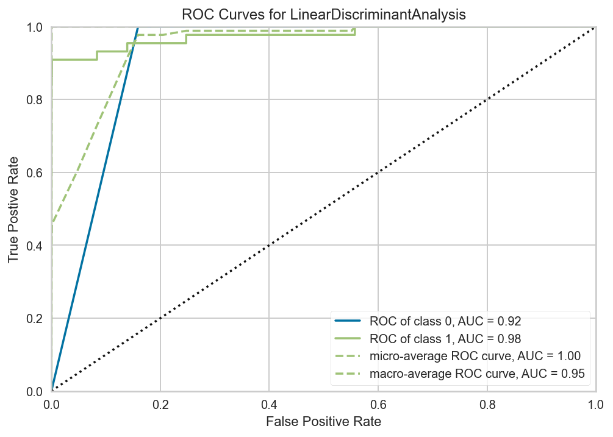

```python
# AUC-ROC plot
pyc.plot_model(clf_lda, plot = 'auc')
```

```python
# confusion matrix
# pyc.plot_model(clf_lda, plot = 'confusion_matrix')
```

```python
# evaluate model
pyc.evaluate_model(clf_lda)
```

# Ensemble Modelling

- [A Comprehensive Guide to Ensemble Learning](https://www.analyticsvidhya.com/blog/2018/06/comprehensive-guide-for-ensemble-models/?utm_source=blog&utm_medium=pycaret-machine-learning-model-seconds).

```
ensemble_model(estimator, method='Bagging', fold=10, n_estimators=10, round=4, verbose=True)

method: 'Bagging' or 'Boosting', default = 'Bagging'
```

```python
# pyc.ensemble_model?
```

```python
clf_dt = pyc.create_model('dt')
```

|  | Accuracy | AUC | Recall | Prec. | F1 | Kappa |
| --- | --- | --- | --- | --- | --- | --- |
| 0 | 0.9985 | 0.8994 | 0.8000 | 0.5333 | 0.6400 | 0.6393 |
| 1 | 0.9980 | 0.6995 | 0.4000 | 0.4000 | 0.4000 | 0.3990 |
| 2 | 0.9987 | 0.8496 | 0.7000 | 0.5833 | 0.6364 | 0.6357 |
| 3 | 0.9992 | 0.8498 | 0.7000 | 0.7778 | 0.7368 | 0.7364 |
| 4 | 0.9987 | 0.9494 | 0.9000 | 0.5625 | 0.6923 | 0.6917 |
| 5 | 0.9982 | 0.8176 | 0.6364 | 0.5000 | 0.5600 | 0.5591 |
| 6 | 0.9980 | 0.7268 | 0.4545 | 0.4545 | 0.4545 | 0.4535 |
| 7 | 0.9990 | 0.8180 | 0.6364 | 0.7778 | 0.7000 | 0.6995 |
| 8 | 0.9978 | 0.8174 | 0.6364 | 0.4375 | 0.5185 | 0.5175 |
| 9 | 0.9995 | 0.8999 | 0.8000 | 0.8889 | 0.8421 | 0.8419 |
| Mean | 0.9985 | 0.8327 | 0.6664 | 0.5916 | 0.6181 | 0.6174 |
| SD | 0.0005 | 0.0727 | 0.1453 | 0.1580 | 0.1284 | 0.1287 |

## Bagging

```python
clf_dt_bagged = pyc.ensemble_model(clf_dt, n_estimators=50,method='Bagging')
```

| Initiated | . . . . . . . . . . . . . . . . . . | 15:37:08 |
| --- | --- | --- |
| Status | . . . . . . . . . . . . . . . . . . | Fitting Fold 8 of 10 |
| ETC | . . . . . . . . . . . . . . . . . . | 2.78 Minutes Remaining |

|  | Accuracy | AUC | Recall | Prec. | F1 | Kappa |
| --- | --- | --- | --- | --- | --- | --- |
| 0 | 0.9992 | 0.8992 | 0.7000 | 0.7778 | 0.7368 | 0.7364 |
| 1 | 0.9992 | 0.8486 | 0.6000 | 0.8571 | 0.7059 | 0.7055 |
| 2 | 0.9997 | 0.9495 | 0.8000 | 1.0000 | 0.8889 | 0.8887 |
| 3 | 0.9995 | 0.8990 | 0.8000 | 0.8889 | 0.8421 | 0.8419 |
| 4 | 0.9997 | 0.9999 | 0.9000 | 0.9000 | 0.9000 | 0.8998 |
| 5 | 0.9995 | 0.8626 | 0.7273 | 1.0000 | 0.8421 | 0.8419 |
| 6 | 0.9987 | 0.8168 | 0.5455 | 0.6667 | 0.6000 | 0.5993 |

[output not shown]

[output cut: 42 more lines]

[output not shown]

```python
# clf_dt_bagged_tuned = pyc.tune_model('dt', ensemble=True,
#                                                 method='Bagging',fold=3, n_iter=10, optimize='Recall')
```

## Boosting

```python
# clf_dt_boosted_tuned = pyc.tune_model('dt', ensemble=True, method='Boosting')
```

## Blending

```
blend_models(estimator_list='All', fold=10, round=4, method='hard', turbo=True, verbose=True)
```

```python
# pyc.blend_models?
```

```python
# blend_soft = pyc.blend_models(estimator_list = [clf_dt, clf_xgb,clf_lda], method = 'soft')
```

```python
# blend_hard = pyc.blend_models(estimator_list = [clf_dt, clf_xgb,clf_lda], method = 'hard')
```

## Stacking

Stacking is another popular technique for ensembling but is less commonly implemented due to practical difficulties. Stacking is an ensemble learning technique that combines multiple models via a meta-model. Another way to think about stacking is that multiple models are trained to predict the outcome and a meta-model is created that uses the predictions from those models as an input along with the original features.

Selecting which method and models to use in stacking depends on the statistical properties of the dataset. Experimenting with different models and methods is the best way to find out which configuration will work best. However as a general rule of thumb, the models with strong yet diverse performance tend to improve results when used in stacking. One way to measure diversity is the correlation of predictions between models. You can analyze this using the plot parameter.

```
stack_models(estimator_list, meta_model=None, fold=10, round=4, method='soft', restack=True, plot=False, finalize=False, verbose=True)
```

```python
# pyc.stack_models?
```

```python
# stack_soft = pyc.stack_models(estimator_list = [clf_dt, clf_xgb,clf_lda], method = 'soft')

# stack_soft2 = pyc.stack_models(estimator_list = [clf_xgb, clf_lda],
#                                           method = 'soft',
#                                          meta_model=clf_dt)
```

```python
# stack_hard = pyc.stack_models(estimator_list = [clf_dt, clf_xgb,clf_lda], method = 'hard')
```

|  | Accuracy | AUC | Recall | Prec. | F1 | Kappa |
| --- | --- | --- | --- | --- | --- | --- |
| 0 | 0.9988 | 0.9432 | 0.5000 | 0.7143 | 0.5882 | 0.5877 |
| 1 | 0.9985 | 0.9298 | 0.7000 | 0.5385 | 0.6087 | 0.6080 |
| 2 | 0.9990 | 0.9246 | 0.6000 | 0.7500 | 0.6667 | 0.6662 |
| 3 | 0.9992 | 0.8721 | 0.7000 | 0.7778 | 0.7368 | 0.7364 |
| 4 | 0.9987 | 0.9483 | 0.7000 | 0.5833 | 0.6364 | 0.6357 |
| 5 | 0.9988 | 0.8874 | 0.6364 | 0.7000 | 0.6667 | 0.6661 |
| 6 | 0.9985 | 0.8328 | 0.5455 | 0.6000 | 0.5714 | 0.5707 |
| 7 | 0.9985 | 0.8420 | 0.5455 | 0.6000 | 0.5714 | 0.5707 |
| 8 | 0.9990 | 0.8729 | 0.7273 | 0.7273 | 0.7273 | 0.7268 |
| 9 | 0.9993 | 0.9878 | 0.9000 | 0.7500 | 0.8182 | 0.8178 |
| Mean | 0.9988 | 0.9041 | 0.6555 | 0.6741 | 0.6592 | 0.6586 |
| SD | 0.0003 | 0.0477 | 0.1108 | 0.0806 | 0.0772 | 0.0773 |

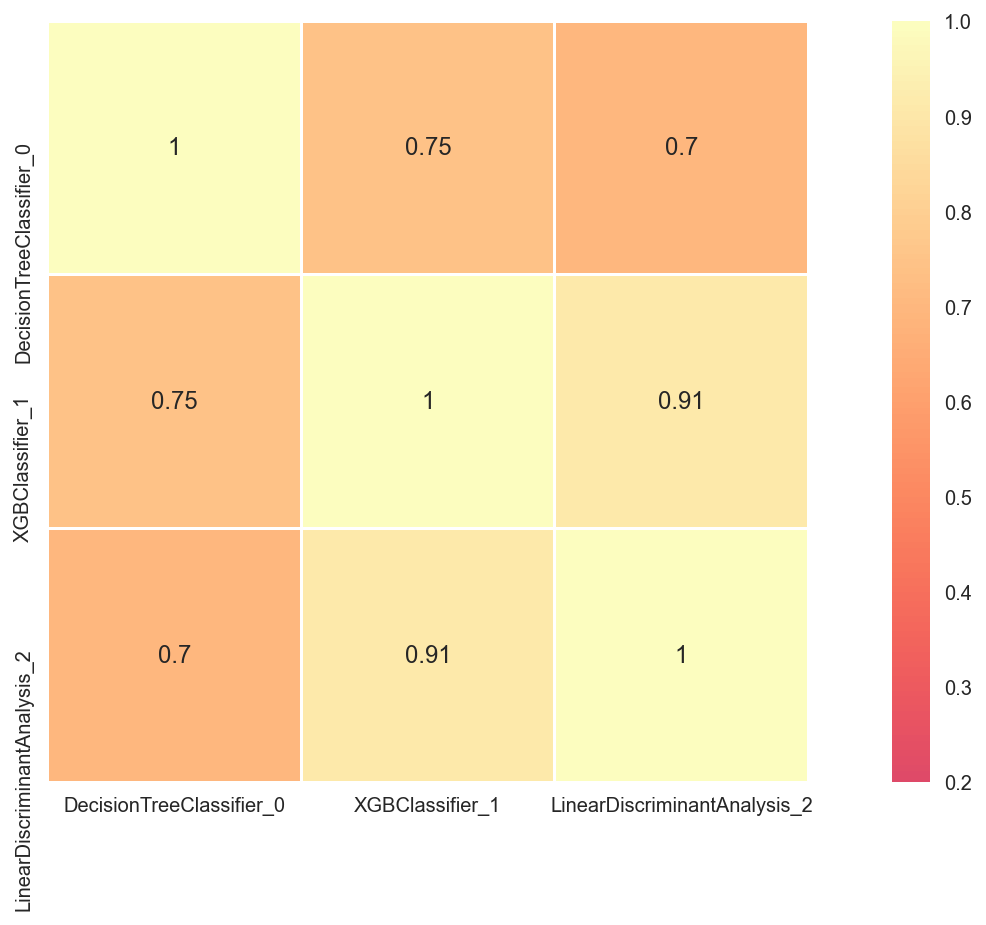

```python
stack_soft_plot = pyc.stack_models([clf_dt,clf_xgb,clf_lda], plot=True)
```

# Model Calibration

When performing classification you often not only want to predict the class label (outcome such as 0 or 1), but also obtain the probability of the respective outcome which provides a level of confidence on the prediction. Some models can give you poor estimates of the class probabilities and some do not even support probability prediction. Well calibrated classifiers are probabilistic and provide outputs in the form of probabilities that can be directly interpreted as a confidence level. PyCaret allows you to calibrate the probabilities of a given model through the calibrate_model() function.

```
calibrate_model(estimator, method='sigmoid', fold=10, round=4, verbose=True)

method : string, default = 'sigmoid'
The method to use for calibration. Can be 'sigmoid' which corresponds to Platt's
method or 'isotonic' which is a non-parametric approach. It is not advised to use
isotonic calibration with too few calibration samples
```

```python
# pyc.calibrate_model?
```

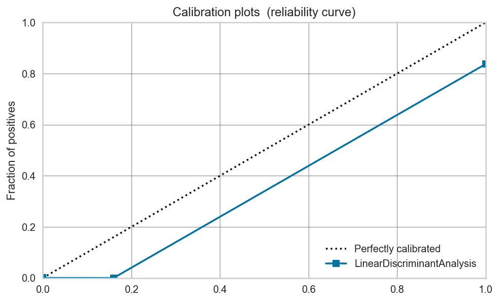

```python
pyc.plot_model(clf_lda_tuned, plot='calibration')
```

```python
clf_lda_tuned_calibrated = pyc.calibrate_model(clf_lda_tuned,fold=5,
                                                  method='sigmoid')
```

|  | Accuracy | AUC | Recall | Prec. | F1 | Kappa |
| --- | --- | --- | --- | --- | --- | --- |
| 0 | 0.9985 | 0.9432 | 0.3333 | 0.6364 | 0.4375 | 0.4368 |
| 1 | 0.9991 | 0.9550 | 0.5238 | 0.9167 | 0.6667 | 0.6662 |
| 2 | 0.9988 | 0.9765 | 0.4286 | 0.8182 | 0.5625 | 0.5620 |
| 3 | 0.9988 | 0.9603 | 0.3333 | 1.0000 | 0.5000 | 0.4996 |
| 4 | 0.9992 | 0.9988 | 0.6500 | 0.8125 | 0.7222 | 0.7218 |
| Mean | 0.9989 | 0.9668 | 0.4538 | 0.8367 | 0.5778 | 0.5773 |
| SD | 0.0002 | 0.0193 | 0.1209 | 0.1218 | 0.1046 | 0.1047 |

```python
mean_row = 'Mean	0.9989	0.9668	0.4538	0.8367	0.5778	0.5773'
df_eval = compare_new_models('lda','tuned,calibrated',mean_row,df_eval=df_eval,sort='Recall')
```

```python
clf_lda_tuned_calibrated_iso = pyc.calibrate_model(clf_lda_tuned,
                            fold=5, method='isotonic')
```

|  | Accuracy | AUC | Recall | Prec. | F1 | Kappa |
| --- | --- | --- | --- | --- | --- | --- |
| 0 | 0.9992 | 0.9474 | 0.7619 | 0.7619 | 0.7619 | 0.7615 |
| 1 | 0.9995 | 0.9550 | 0.7619 | 0.9412 | 0.8421 | 0.8419 |
| 2 | 0.9992 | 0.9699 | 0.7619 | 0.8000 | 0.7805 | 0.7801 |
| 3 | 0.9991 | 0.9601 | 0.5714 | 0.8571 | 0.6857 | 0.6853 |
| 4 | 0.9992 | 0.9989 | 0.7500 | 0.7895 | 0.7692 | 0.7689 |
| Mean | 0.9992 | 0.9663 | 0.7214 | 0.8299 | 0.7679 | 0.7675 |
| SD | 0.0001 | 0.0179 | 0.0751 | 0.0637 | 0.0499 | 0.0500 |

```python
mean_row = 'Mean	0.9992	0.9663	0.7214	0.8299	0.7679	0.7675'
df_eval = compare_new_models('lda','tuned,calibratedIsotonic',mean_row,df_eval=df_eval,sort='Recall')
```

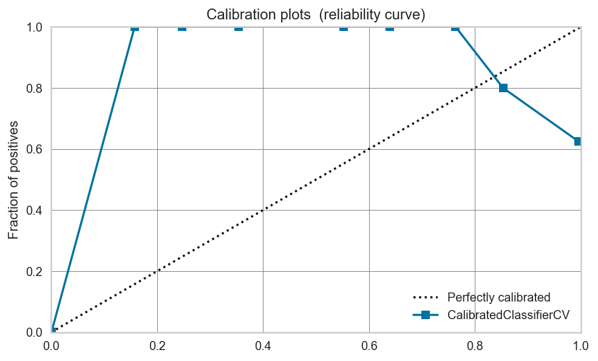

```python
pyc.plot_model(clf_lda_tuned_calibrated, plot='calibration')
```

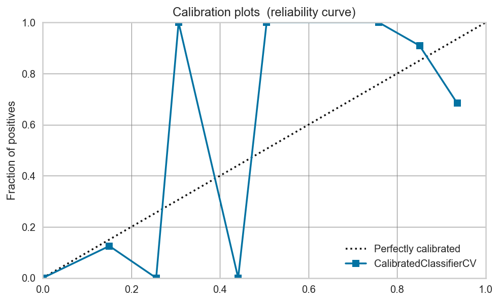

```python
pyc.plot_model(clf_lda_tuned_calibrated_iso, plot='calibration')
```

# Model Interpretation

```python
df_eval
```

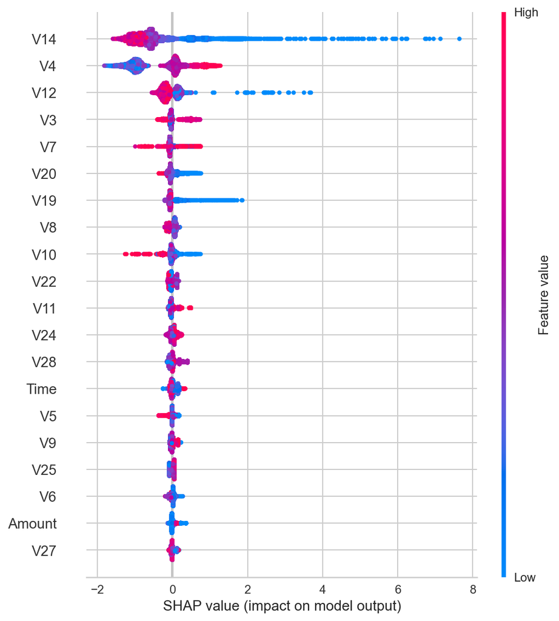

```python
# interpret_model: SHAP
pyc.interpret_model(clf_xgb)
```

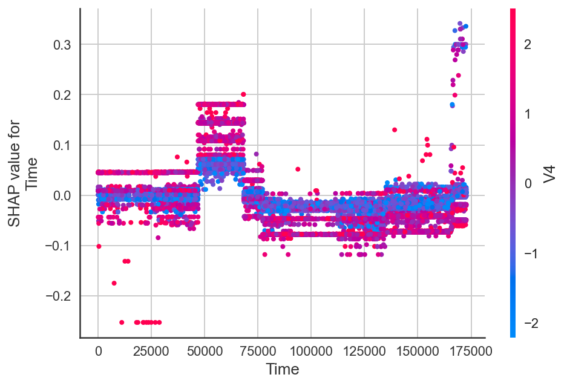

```python
# interpret model : Correlation
pyc.interpret_model(clf_xgb,plot='correlation')
```

# Model Predictions

```python
df_test.iloc[:5,-5:]
```

|  | V26 | V27 | V28 | Amount | Class |
| --- | --- | --- | --- | --- | --- |
| 248750 | -0.775158 | 0.261012 | 0.058359 | 18.70 | 0 |
| 161573 | -0.235203 | -0.036910 | -0.227111 | 9.99 | 0 |
| 65893 | 0.011709 | 0.029830 | -0.080522 | 112.00 | 0 |
| 12836 | 0.974426 | -0.067625 | 0.007633 | 23.27 | 0 |
| 132224 | -0.252303 | 0.009928 | 0.015153 | 74.97 | 0 |

```python
df_preds = pyc.predict_model(clf_lda_tuned_calibrated,df_test)
df_preds.iloc[:5,-5:]
```

|  | V28 | Amount | Class | Label | Score |
| --- | --- | --- | --- | --- | --- |
| 0 | 0.058359 | 18.70 | 0 | 0 | 0.0009 |
| 1 | -0.227111 | 9.99 | 0 | 0 | 0.0008 |
| 2 | -0.080522 | 112.00 | 0 | 0 | 0.0008 |
| 3 | 0.007633 | 23.27 | 0 | 0 | 0.0007 |
| 4 | 0.015153 | 74.97 | 0 | 0 | 0.0008 |

# Model Persistence

```python
# save the model
pyc.save_model(clf_lda_tuned, '../models/clf_lda_tuned_calibrated.pkl')
```

```
Transformation Pipeline and Model Succesfully Saved
```

```python
# load model
clf_lda_tuned_calibrated = pyc.load_model(model_name='../models/clf_lda_tuned_calibrated.pkl')
```

```
Transformation Pipeline and Model Sucessfully Loaded
```

```python
# save entire experiment
pyc.save_experiment("../models/experiment_may31_2020")
```

```
Experiment Succesfully Saved
```

```python
saved_experiment = pyc.load_experiment('../models/experiment_may31_2020')
```

|  | Object |
| --- | --- |
| 0 | Classification Setup Config |
| 1 | X_training Set |
| 2 | y_training Set |
| 3 | X_test Set |
| 4 | y_test Set |
| 5 | Transformation Pipeline |
| 6 | Compare Models Score Grid |
| 7 | Extreme Gradient Boosting |
| 8 | Extreme Gradient Boosting Score Grid |
| 9 | CatBoost Classifier |
| 10 | CatBoost Classifier Score Grid |
| 11 | Linear Discriminant Analysis |
| 12 | Linear Discriminant Analysis Score Grid |
| 13 | Tuned XGBClassifier |
| 14 | Tuned XGBClassifier Score Grid |
| 15 | Tuned <catboost.core.CatBoostClassifier object... |
| 16 | Tuned <catboost.core.CatBoostClassifier object... |
| 17 | Tuned LinearDiscriminantAnalysis |
| 18 | Tuned LinearDiscriminantAnalysis Score Grid |
| 19 | Compare Models Score Grid |
| 20 | Tuned LinearDiscriminantAnalysis |
| 21 | Tuned LinearDiscriminantAnalysis Score Grid |
| 22 | Decision Tree |
| 23 | Decision Tree Score Grid |
| 24 | BaggingClassifier |
| 25 | BaggingClassifier Score Grid |
| 26 | Stacking Classifier (Single Layer) |
| 27 | Stacking Classifier (Single Layer) Score Grid |
| 28 | CalibratedClassifierCV |
| 29 | CalibratedClassifierCV Score Grid |
| 30 | CalibratedClassifierCV |
| 31 | CalibratedClassifierCV Score Grid |
| 32 | CalibratedClassifierCV |
| 33 | CalibratedClassifierCV Score Grid |
| 34 | CalibratedClassifierCV |
| 35 | CalibratedClassifierCV Score Grid |
| 36 | CalibratedClassifierCV |
| 37 | CalibratedClassifierCV Score Grid |
| 38 | CalibratedClassifierCV |
| 39 | CalibratedClassifierCV Score Grid |
| 40 | CalibratedClassifierCV |
| 41 | CalibratedClassifierCV Score Grid |
| 42 | CalibratedClassifierCV |
| 43 | CalibratedClassifierCV Score Grid |
| 44 | CalibratedClassifierCV |
| 45 | CalibratedClassifierCV Score Grid |
| 46 | Compare Models Score Grid |
| 47 | CalibratedClassifierCV |
| 48 | CalibratedClassifierCV Score Grid |

```python
saved_experiment[47]
```

```
CalibratedClassifierCV(base_estimator=LinearDiscriminantAnalysis(n_components=None,
                                                                 priors=None,
                                                                 shrinkage=None,
                                                                 solver='lsqr',
                                                                 store_covariance=False,
                                                                 tol=0.0001),
                       cv=5, method='isotonic')
```

# Time taken

```python
time_taken = time.time() - time_start_notebook
h,m = divmod(time_taken,60*60)
print('Time taken to run whole notebook: {:.0f} hr '\
      '{:.0f} min {:.0f} secs'.format(h, *divmod(m,60)))

import subprocess
subprocess.call(['python', '-m', 'nbconvert', '*.ipynb'])
```

```
---------------------------------------------------------------------------
NameError                                 Traceback (most recent call last)
<ipython-input-188-431efb828dbf> in <module>
----> 1 time_taken = time.time() - time_start_notebook
      2 h,m = divmod(time_taken,60*60)
      3 print('Time taken to run whole notebook: {:.0f} hr '\
      4       '{:.0f} min {:.0f} secs'.format(h, *divmod(m,60)))
      5

NameError: name 'time_start_notebook' is not defined
```

```python
%%bash
mkdir -p html
mv *.html html/
```

```
mv: rename *.html to html/*.html: No such file or directory
```

[output not shown]